# Making Salary Predictions

## Simple Linear Regression

- Simple linear regression is a technique that is appropriate to understand the association between one independent (or predictor) variable and one continuous dependent (or outcome) variable.The outcome variable is also called the response or dependent variable, and the risk factors and confounders are called the predictors, or explanatory or independent variables. In regression analysis, the dependent variable is denoted "Y" and the independent variables are denoted by "X". Yearsworked is the independant variable and salary is the dependant variable. (http://sphweb.bumc.bu.edu/otlt/MPH-Modules/BS/BS704_Correlation-Regression/)
- The easiest regression model is the simple linear regression which is represented by the following formula:

# Y = β0 + β1 * x1 + ε.

- Y = Dependent variable/ Outcome
- β0 = The intercept on the Y-axis
- β = The slope or coefficient or parameter of the model
- x1 = Independent variable/ Predictor
- ε = The error, or residual

```python
#%pylab inline
import matplotlib.pyplot as plt
import seaborn as sns
%matplotlib inline
import pandas as pd
import numpy as np
from scipy import stats
import statsmodels.api as sm
import statsmodels.formula.api as smf
from sklearn import datasets, linear_model
from sklearn.linear_model import LinearRegression
from sklearn.model_selection import train_test_split
from sklearn.metrics import mean_squared_error
```

```python
#Import salary.csv as data using pd.read_csv method.
dataframe = pd.read_csv("salary.csv")
```

```python
#Use .dropna() to drop all nan values.
dataframe = pd.read_csv("salary.csv").dropna()
```

We select the salary column from the salary dataframe.

```python
data = dataframe['salary']
```

The data dataframe file contains the following data, displayed using the head() function.

```python
data.head()
```

```
0    53000.0
1    58000.0
2    45500.0
3    35782.0
4    34731.0
Name: salary, dtype: float64
```

# Below we split the data.

- We will need to first split up our data into an X_array that contains the features to train on, and a y_array with the target variable, in this case the Salary column.

```python
X_train, X_test, y_train, y_test = train_test_split(dataframe, data, test_size=0.20, random_state=42)
```

```python
#Below we display the first 5 rows of the data we just split into training and testing.
```

```python
print("X_train:")
print(X_train.head())
print(X_train.shape)

print("X_test:")
print(X_test.head())
print(X_test.shape)
```

```
X_train:
          salary  exprior  yearsworked  yearsrank  market  degree  otherqual  \
321  55608.00000        1           25         21    0.96       1          0
330  48327.00000       25            2          2    0.78       1          0
173  61453.00000        0           15          0    1.21       1          0
273  65432.00000        0           23         12    0.99       1          0
493  44410.85547        7           12         10    0.72       1          0

     position  male  Field  yearsabs
321         2     1      4         0
330         2     1      4         1
173         2     1      1         0
273         3     1      1         1
493         2     0      3        51
(410, 11)
X_test:
      salary  exprior  yearsworked  yearsrank  market  degree  otherqual  \
305  48456.0        1           24         16    0.85       1          0
497  48681.0        0           19         12    1.05       1          0
440  41915.0        0           10          4    0.82       1          0
153  42954.0        6            9          0    0.92       1          0
499  45669.0        2           18          5    0.73       1          0

     position  male  Field  yearsabs
305         2     1      4         0
497         2     0      4        52
440         2     0      4         1
153         3     1      3         1
499         2     0      3        56
(103, 11)
```

Ordinary Least Squares regression (OLS) is more commonly named linear regression (simple or multiple depending on the number of explanatory variables). smf stands for statsmodels formula.

```python
# Create linear regression object
model = linear_model.LinearRegression()
```

```python
# Train the lm (model) using the training sets
model = smf.ols(formula='salary ~ yearsworked', data=X_train).fit()
```

# Training models will be presented in RED and Testing models will be in BLUE.

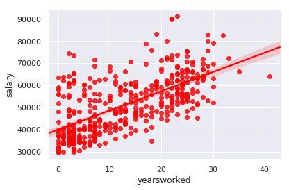

```python
sns.set(color_codes=True)
sns.regplot(x="yearsworked", y="salary", color = "red", data=X_train);
```

```python
model.summary()
```

OLS Regression Results

| Dep. Variable: | salary | R-squared: | 0.413 |
| --- | --- | --- | --- |
| Model: | OLS | Adj. R-squared: | 0.411 |
| Method: | Least Squares | F-statistic: | 286.9 |
| Date: | Mon, 20 May 2019 | Prob (F-statistic): | 4.02e-49 |
| Time: | 15:50:05 | Log-Likelihood: | -4348.0 |
| No. Observations: | 410 | AIC: | 8700. |
| Df Residuals: | 408 | BIC: | 8708. |
| Df Model: | 1 |  |  |
| Covariance Type: | nonrobust |  |  |

|  | coef | std err | t | P>\|t\| | [0.025 | 0.975] |
| --- | --- | --- | --- | --- | --- | --- |
| Intercept | 3.999e+04 | 813.810 | 49.141 | 0.000 | 3.84e+04 | 4.16e+04 |
| yearsworked | 867.0014 | 51.183 | 16.939 | 0.000 | 766.387 | 967.616 |

| Omnibus: | 49.377 | Durbin-Watson: | 2.094 |
| --- | --- | --- | --- |
| Prob(Omnibus): | 0.000 | Jarque-Bera (JB): | 63.813 |
| Skew: | 0.932 | Prob(JB): | 1.39e-14 |
| Kurtosis: | 3.509 | Cond. No. | 26.9 |

Warnings:  
[1] Standard Errors assume that the covariance matrix of the errors is correctly specified.

#### Q1.1. Does the model significantly predict the dependent variable? Report the amount of variance explained (R^2) and significance value (p) to support your answer.

The coefficient of determination, R^2, is a measure of how well the variation of one variable explains the variation of the other, and corresponds to the percentage of the variation explained by a best-fit regression line which is calculated for the data. (https://www.colby.edu/biology/BI17x/regression.html)

- The model has a coefficent of determination of R^2 = 0.413 (41.3%). This means that the model has a regression line with 41.3% approximation of the real data points. The p-value for both Const and Yearsworked are 0.000. A low p-value (< 0.5) indicates that you can reject the null hypothesis, meaning that a low p-value is likely to be a meaningful addition to your model because changes in the predictor's value are related to changes in the response variable. This means that the model can significantly predict the dependent variable (Salary).
- The model significantly predicts the depended variable given that is has an an r2 of 0.413 and a p-value (0.000) that is less than the 0.5 requirement.

#### Q1.2. What percentage of the variance in employees’ salaries is accounted for by the number of years they have worked?

- The variance is a good metric to be used for this purpose, as it measures how far a set of numbers are spread out (from their mean value).
- This is where the “% variance explained” comes from. By the way, for regression analysis, it equals the correlation coefficient R-squared.

```python
model.rsquared
```

```
0.41290134147778423
```

#### Q2. What does the unstandardized coefficient (B or 'coef' in statsmodels) tell you about the relationship between Years Worked and Salary?

```python
lm.conf_int()
```

|  | 0 | 1 |
| --- | --- | --- |
| Intercept | 38392.014244 | 41591.583589 |
| yearsworked | 766.386944 | 967.615876 |

#### Q3. What do the 95% confidence intervals [0.025, 0.975] mean?

#### Q4.Calculate the expected salary for someone with 12 years’ work experience.

```python
predictions = pd.DataFrame({'yearsworked': [12]})
model.predict(predictions)
```

```
0    50395.815838
dtype: float64
```

A person with 12 years experience would earn $50395.82.

#### Q5. Calculate the expected salary for someone with 80 years’ work experience. Are there any problems with this prediction? If so, what are they?

```python
predictions = pd.DataFrame({'yearsworked': [80]})
model.predict(predictions)
```

```
0    109351.911723
dtype: float64
```

A person with 80 years experience would earn $109351.91.

#### Q6. We have only looked at the number of years an employee has worked. What other employee characteristics might influence their salary?

- exprior (Years of experience prior to working in this field)
- Yearsrank
- Degree (Education level)
- Position
- Gender (The male avg salary is higher than that of women)

## Now fit your model to your test set.

```python
# Create linear regression object for model_test
model_test = linear_model.LinearRegression()
```

```python
# Train the model using the test sets
model_test = smf.ols(formula='yearsworked ~ salary', data=X_test).fit()
```

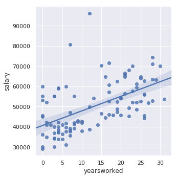

```python
sns.set(color_codes=True)
sns.lmplot(x="yearsworked", y="salary", data=X_test);
```

```python
model_test.summary()
```

OLS Regression Results

| Dep. Variable: | yearsworked | R-squared: | 0.302 |
| --- | --- | --- | --- |
| Model: | OLS | Adj. R-squared: | 0.295 |
| Method: | Least Squares | F-statistic: | 43.70 |
| Date: | Mon, 20 May 2019 | Prob (F-statistic): | 1.83e-09 |
| Time: | 15:55:15 | Log-Likelihood: | -358.76 |
| No. Observations: | 103 | AIC: | 721.5 |
| Df Residuals: | 101 | BIC: | 726.8 |
| Df Model: | 1 |  |  |
| Covariance Type: | nonrobust |  |  |

|  | coef | std err | t | P>\|t\| | [0.025 | 0.975] |
| --- | --- | --- | --- | --- | --- | --- |
| Intercept | -7.9257 | 3.261 | -2.430 | 0.017 | -14.395 | -1.457 |
| salary | 0.0004 | 6.33e-05 | 6.611 | 0.000 | 0.000 | 0.001 |

| Omnibus: | 1.221 | Durbin-Watson: | 1.645 |
| --- | --- | --- | --- |
| Prob(Omnibus): | 0.543 | Jarque-Bera (JB): | 1.304 |
| Skew: | -0.235 | Prob(JB): | 0.521 |
| Kurtosis: | 2.712 | Cond. No. | 2.14e+05 |

Warnings:  
[1] Standard Errors assume that the covariance matrix of the errors is correctly specified.  
[2] The condition number is large, 2.14e+05. This might indicate that there are  
strong multicollinearity or other numerical problems.

#### Q7. How does your model compare when running it on the test set - what is the difference in the Root Mean Square Error (RMSE) between the training and test sets?

```python
model_prediction = model.predict(X_train.yearsworked)
```

```python
np.sqrt(mean_squared_error(y_train, model_prediction))
```

```
9758.65143908335
```

```python
model.rsquared
```

```
0.41290134147778423
```

```python
model_test_prediction = model.predict(X_test.yearsworked)
```

```python
np.sqrt(mean_squared_error(y_test, model_test_prediction))
```

```
10510.898741073628
```